# Mandatory assignment 3

Eirik Sakariassen

```r
rm(list=ls()) # deletes all stored variables
```

# Problem 1

### a)

Given a dataset with unknown distribution, the distribution of sample means, calculated from repeated sampling, will approximate the normal distribution as the samples get larger. Generally OK when sample size n >= 30. The CLT says that:
$$Z=\frac{\bar{X}-E(\bar{X})}{\sqrt{Var(\bar{X})}}= \frac{\bar{X}-\mu}{\sqrt{\sigma^{2}/n}} \approx N(0,1)$$
Based on this, a CLT based simulation algorithm for the standard normal distribution can be:

1. Select any distribution
2. Sample n>=30 independent r.v.s. from the given distribution
3. Set $Z=\frac{\bar{X}-\mu}{\sqrt{\sigma^{2}/n}}$, where $\bar{X}$ and n is based on step 2, and $\mu$ and $\sigma$ comes from the original distribution in step 1
4. Repeat step 2-3 a large number of times. The simulated Z values will approximate a standard normal distribution

From the Berry Essen theorem, we have that
$$E(X_{i})=0, \quad E(X_{i}^{2})=\sigma^{2}>0, \quad E(|X_{i}|^{3})=p^{<\infty}$$
where $X_{1},..,X_{n}$ are i.i.d r.v.s. A random variable X which we may apply this theorem can be X$\sim$Unif[-1,1]. Then we have:
$$E(X)=\frac{1}{2}(a+b) = \frac{-1+1}{2}=0, OK$$
$$Var(X)=\frac{1}{12}(b-a)^2 = \frac{1^{2}-2(-1)(1)+(-1)^{2}}{12}=\frac{1}{3}$$
Then we can check
$$E(X^{2}) = \frac{1}{3}(a^{2}+ab+b^{2}) = \frac{(-1)^{2}+(-1)(1) + 1^{2}}{3}= \frac{1}{3}=Var(X), OK$$
$$E(|X|^{3})= \int_{-\infty}^{0}x^{3}f(x)dx+\int_{0}^{\infty}x^{3}f(x)dx$$
$$\iff -\int_{-1}^{0}x^{3}\frac{1}{b-a}dx +\int_{0}^{1}x^{3}\frac{1}{b-a}dx = 0.25$$
Let $Y_{n}=\frac{x_{1}+..+x_{n}}{\sqrt{n}\sigma}$ and let $F_{n}$ be its cdf: $F_{n}(x)=P(Y_{n}<=x)$. Then,
$$|F_{n}(x)-\phi(x)| <= \frac{0.5p}{\sigma^{3}\sqrt{n}}$$
where $\phi$ is the cdf of N(0,1). The smallest value of n for which the bound in BE is <= 0.02 is:
$$0.02 >= \frac{0.5p}{\sigma^{3}\sqrt{n}}$$
$$\implies n>= \big (\frac{0.5p}{\sigma^{3}0.02} \big )^{2} = \big (\frac{0.5 \cdot 0.25}{\sqrt{\frac{1}{3}}^{3}0.02} \big )^{2} \approx 1055$$

### $b)^R$

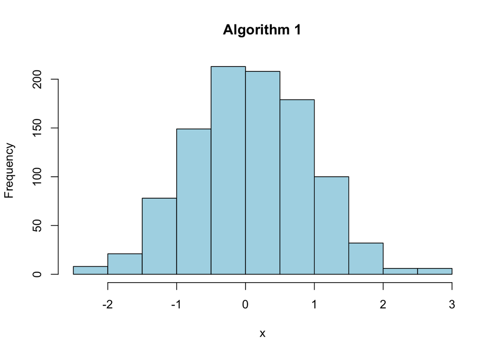

```r
#ALGORITHM 1
alg1 <- function(N){
  resVec <- rep(0,N)
  for (i in 2:N){
    s <- resVec[i-1]
    t <- runif(1, s-1, s+1)
    alfa <- exp(-(t^2 - s^2)/2)
    u <- runif(1)
    if(u <= alfa){
      resVec[i] <- t
    }else{
      resVec[i] <- s
    }
  }
  return(resVec)
}

alg1_time <- system.time(alg1_res <- alg1(1000))
hist(alg1_res , col ="lightblue", main="Algorithm 1", xlab = "x")
```

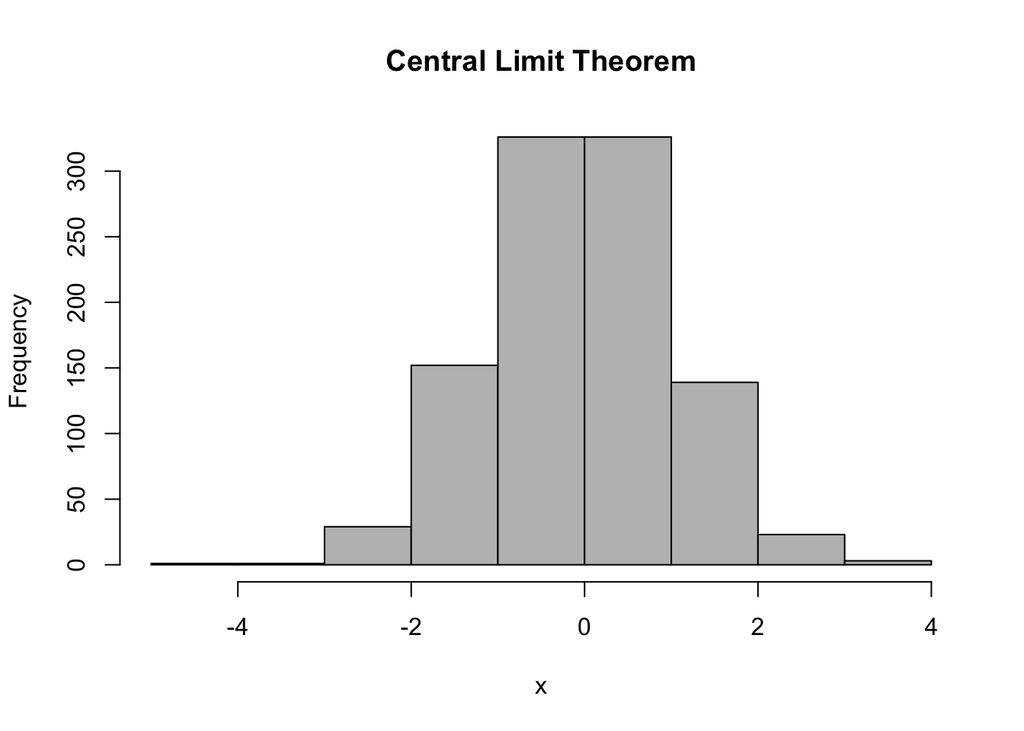

```r
#Central Limit Theorem
clt <- function(n=1055, N=1000){
  mu <- 0
  Fnvar <- 1/3
  clt<-c()
  for (i in 1:N) {
    sample_mean <- mean(runif(n,min=-1,max=1))
    clt[i] <- (sample_mean - mu)/(sqrt(Fnvar)/sqrt(n))
  }
  return(clt)
}

CLT_time <- system.time(clt_res <- clt())
hist(clt_res, col ="grey", main="Central Limit Theorem", xlab = "x")
```

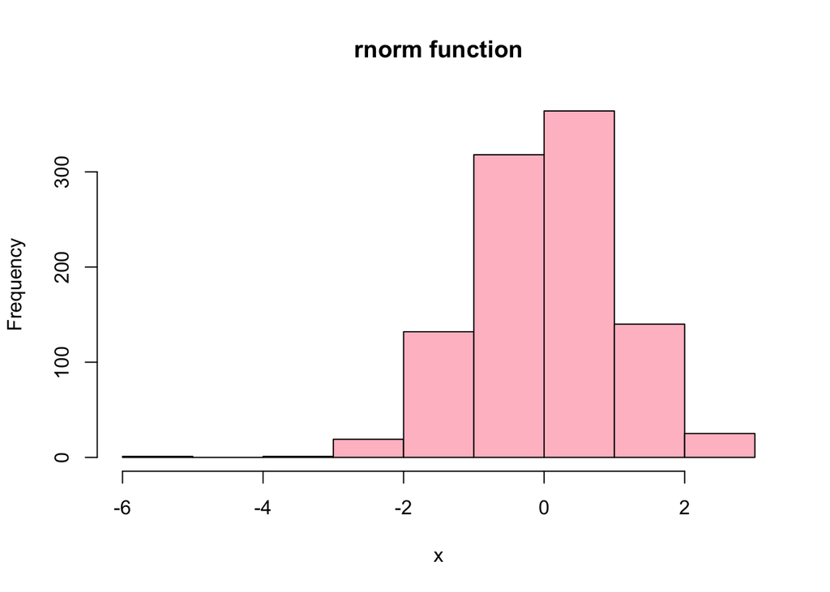

```r
#From rnorm
rnorm_time <- system.time(rnorm_res <- rnorm(1000))
hist(rnorm_res, col ="pink", main="rnorm function", xlab = "x")
```

```r
#################################################################################
# Present the main results in a table
runtimes=data.frame("MCMC"=alg1_time["elapsed"],"CLT"=CLT_time["elapsed"],"rnorm"=rnorm_time["elapsed"])
kable(runtimes,  caption= "Execution times")
```

Execution times

|  | MCMC | CLT | rnorm |
| --- | --- | --- | --- |
| elapsed | 0.032 | 0.045 | 0 |

### $c)^R$

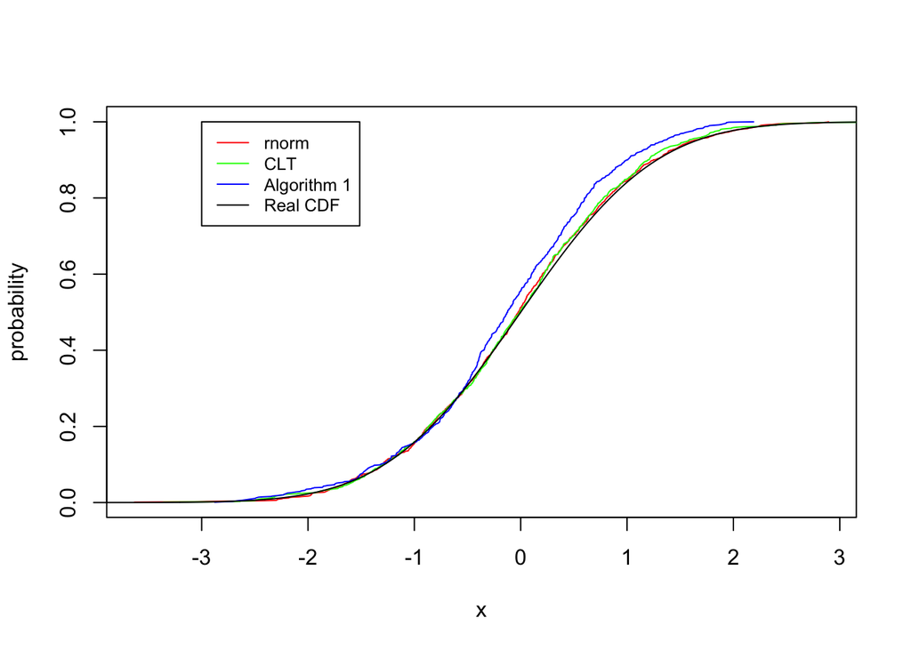

```r
ecdfSim <- function(dataset){
  sortedSet <- sort(dataset)
  ecdfVec <- c()
  for (i in 1:length(sortedSet)){
    ecdfVec[i] <- sum(dataset<=sortedSet[i])/length(dataset)
  }
  return(list("x" = sortedSet, "y" = ecdfVec) )
}

#Result from all functions
rnormRes <- rnorm(1000)
cltRes <- clt(1000)
alg1Res <- alg1(1000)

#ecdf of the functions
rnorm_ecdf <- ecdfSim((rnormRes))
clt_ecdf <- ecdfSim((cltRes))
alg1_ecdf <- ecdfSim((alg1Res))
real_cdf <- seq(-4,4,length=1000)

# Create a plot
plot(rnorm_ecdf$x,rnorm_ecdf$y,type="l",col="red", xlab="x", ylab="probability")
lines(clt_ecdf$x,clt_ecdf$y,col="green")
lines(alg1_ecdf$x,alg1_ecdf$y,col="blue")
lines(real_cdf,pnorm(real_cdf,0,1))

legend(-3, 1, legend=c("rnorm", "CLT", "Algorithm 1", "Real CDF"),
       col=c("red", "green", "blue", "black"), lty=1, cex=0.8)
```

```r
kolmogorovSmirnovTest <- function(dataset1, dataset2){
  t <- max(abs(dataset1-dataset2))
  return(t)
}

permutationTest <- function(P,dataset1,dataset2){
  t <- kolmogorovSmirnovTest(dataset1,dataset2) #The max difference between them originally
  Z <- c(dataset1,dataset2) #Pooled data
  size <- length(Z)
  resVec <- c()
  for(i in 1:P){ #Permutate them P times
    permData <- sample(Z,size=size,replace=FALSE) #Permutation of Z
    x <- permData[1:(size/2)] #First half
    y <- permData[((size/2)+1):size] #Second half
    resVec[i] <- kolmogorovSmirnovTest(x,y)
  }
  #number of times the recorded differences were more extreme than the original difference
  pvalue <- (length(resVec[resVec>t]))/P
  return(list("pvalue" = pvalue, "t" = t) )
}

test_rnorm_alg1 <- permutationTest(500,rnorm_ecdf$y,alg1_ecdf$y) #Between rnorm and alg1
test_clt_alg1 <- permutationTest(500,clt_ecdf$y,alg1_ecdf$y) #Between clt and alg1
test_clt_rnorm <- permutationTest(500,clt_ecdf$y,rnorm_ecdf$y) #Between clt and rnorm
alfa <- 0.05
#Check if pval > alfa (then null hypo is true and they are the same dist)
test_rnorm_alg1
```

```
## $pvalue
## [1] 1
##
## $t
## [1] 0.004
```

```r
test_clt_alg1
```

```
## $pvalue
## [1] 1
##
## $t
## [1] 0.004
```

```r
test_clt_rnorm
```

```
## $pvalue
## [1] 1
##
## $t
## [1] 0
```

```r
##The inbuild ks.test function will produce the exact same results
#ks.test(rnorm_ecdf$y,alg1_ecdf$y,b=500)
#ks.test(clt_ecdf$y,alg1_ecdf$y,b=500)
#ks.test(clt_ecdf$y,rnorm_ecdf$y,b=500)

cat(ifelse(test_rnorm_alg1$pvalue <= alfa,"We reject the null hypothesis for rnorm and alg1","We keep the null hypothesis for rnorm and alg1"))
```

```
## We keep the null hypothesis for rnorm and alg1
```

```r
cat(ifelse(test_clt_alg1$pvalue <= alfa,"We reject the null hypothesis for clt and alg1","We keep the null hypothesis for clt and alg1"))
```

```
## We keep the null hypothesis for clt and alg1
```

```r
cat(ifelse(test_clt_rnorm$pvalue <= alfa,"We reject the null hypothesis for clt and rnorm","We keep the null hypothesis for clt and rnorm"))
```

```
## We keep the null hypothesis for clt and rnorm
```

# Problem 2

### a)

Simulation algorithm:

1. Start at $W_{0}$=(x,y,z)$\in$D ($D\subset \mathbb{R}^{3}$)
2. Specify a time coordinate $t\in[0,\infty)$
3. Sample a standard Brownian motion $(W_{t})_{t>=0}$ by sampling the next step from a standard normal distribution; $\triangle x, \triangle y, \triangle z \sim N(0,1)$, then $W_{t}=W_{t-1}+(\triangle x, \triangle y, \triangle z)$
4. Repeat step 3 until $W_{t} \notin D$ or $t=T$ (iteration T equals limit of t in 2.)
5. If $T\in [t,\infty)$, do f($W_{t}$), else do g($W_{t}$)
6. Run 1-5 a large number of times and take the mean of the results

### $b)^R$

```r
simFeynmanKac <- function(Nsim,t,x,y,z){
  resVec <- c()
  for(i in 1:Nsim){
    coord <- c(x,y,z) #Start coordinates
    T <- 0
    while(TRUE){ #until it exits D or passes t
      coord <- coord + rnorm(3)
      T <- T + 1
      if(T == t || ((sqrt(sum(coord^2)) >= 5))){
        break
      }
    }
    if(sqrt(sum(coord^2)) <= 5){#F
      resVec[i] <- coord[1]^2 + coord[2]^2
    }else{ #G
      check <- coord[1]^2 + coord[2]^2 #x^2 + y^2
      resVec[i] <- min(check,5)
    }
  }
  return(mean(resVec))
}

solution =data.frame("t=1"=simFeynmanKac(10000,1,0,0,0),
                    "t=5"=simFeynmanKac(10000,5,0,0,0),
                    "t=10"=simFeynmanKac(10000,10,0,0,0),
                    "t=100"=simFeynmanKac(10000,100,0,0,0),
                    "t=10000"=simFeynmanKac(10000,10000,0,0,0))
kable(solution, caption= "Heat equation solutions")
```

Heat equation solutions

| t.1 | t.5 | t.10 | t.100 | t.10000 |
| --- | --- | --- | --- | --- |
| 1.992474 | 6.451019 | 5.879298 | 4.789302 | 4.778422 |

# Problem 3

### a)

f(x) is the pdf of of the contineous r.v. X if:

1. f(x)>= 0 for all $X\in R$
2. $\int_{-\infty}^{\infty}f(x)dx=1$
3. P(a<X<b) = $\int_{a}^{b}f(x)dx$

We have that
$$f(x)=\frac{1}{2b}e^{-\frac{|x-\mu|}{b}}, x\in(-\infty,\infty),$$
where $\mu \in(-\infty,\infty)$ and b>0. Proof:

1. We have that b>0 $\frac{1}{2b}$>0. Also $e^{-\frac{|x-\mu|}{b}}$>=0, hence f(x)>=0
2. $$\int_{-\infty}^{\infty}\frac{1}{2b}e^{-\frac{|x-\mu|}{b}}dx \quad set \quad u=x-\mu$$
   $$\implies \int_{-\infty}^{\infty}\frac{1}{2b}e^{-\frac{|u|}{b}}du$$
   which is symmetric around 0,
   $$\implies 2\int_{0}^{\infty}\frac{1}{2b}e^{-\frac{|u|}{b}}du = \frac{1}{b}\int_{0}^{\infty}e^{-\frac{|u|}{b}}du$$
   $$\implies \frac{1}{b}[-be^{-\frac{|u|}{b}}]_{0}^{\infty} = -e^{-\frac{|u|}{b}}|_{0}^{\infty}$$
   $$\implies 0- (-1) = 1$$
3. $$P(-\infty < X < \infty) = \int_{-\infty}^{\infty}f(x)dx = \int_{-\infty}^{\infty}\frac{1}{2b}e^{-\frac{|x-\mu|}{b}}dx = 1$$

The inverse transfer method may be used to simulate data from a contineous distribution with pdf f(x). This is quite easy if the cdf F(x) is easy to invert. The theorem states that:

If X is a contineous r.v. with cdf F(x) then $U=F(X) \sim Unif[0,1]$$ The simulation algorithm is as follows:

1. Generate U Unif[0,1]
2. Let x = $F^{-1}(U)$

So our first step is to find the cdf F(x), then invert it.

$$F(x) = \int_{-\infty}^{x}f(y)dy =\int_{-\infty}^{x}\frac{1}{2b}e^{-\frac{|y-\mu|}{b}} dy$$
$$\implies F(x) = \begin{cases}
\frac{1}{2}e^{(\frac{x-\mu}{b})} \quad if \quad x<\mu\\
1 - \frac{1}{2}e^{-(\frac{x.\mu}{b})} \quad otherwise
\end{cases}$$
We have two cases for x. First look at the case where $x<\mu$:
$$U=\frac{1}{2}e^{(\frac{x-\mu}{b})}$$
$$\iff 2U=e^{(\frac{x-\mu}{b})}$$
$$\iff ln(2U)=\frac{x-\mu}{b}$$
$$\implies x=\mu + b ln(2U)$$
Then, for $x>=\mu$ we have:
$$U=1-\frac{1}{2}e^{-(\frac{x-\mu}{b})}$$
$$\iff 2(1-U)=e^{-(\frac{x-\mu}{b})}$$
$$\iff ln(2(1-U))=-\frac{x-\mu}{b}$$
$$\implies x = \mu - bln(2-2U)$$
We may then combine the two values for x into:
$$x=\mu - sgn(x-\mu)bln(1+sgn(x-\mu)-sgn(x-\mu)2U)$$
Use the fact that $sgn(x-\mu)=sgn(U-\frac{1}{2})$ to simplify it. We end up with the inverse function:
$$F(U)^{-1}=\mu - bsgn(U-0.5)ln(1-2|U-0.5|)$$
which is the function we use for step 2 in the algorithm described above.

### b)

1. Set $X_{0}=0$
2. Sample a uniform distributed number from [s-1,s+1] where s=$X_{i-1}$
3. Compute the acceptance function $\alpha(s,t)=\frac{\pi_{t}}{\pi_{s}} = e^{\frac{|s-\mu|-|t-\mu|}{b}}$
4. Sample u$\sim$Unif[0,1]
5. If $u<=\alpha(s,t)$, set $X_{i}=t$, else set $X_{i}=s$
6. Repeat 2-5 a large number of times

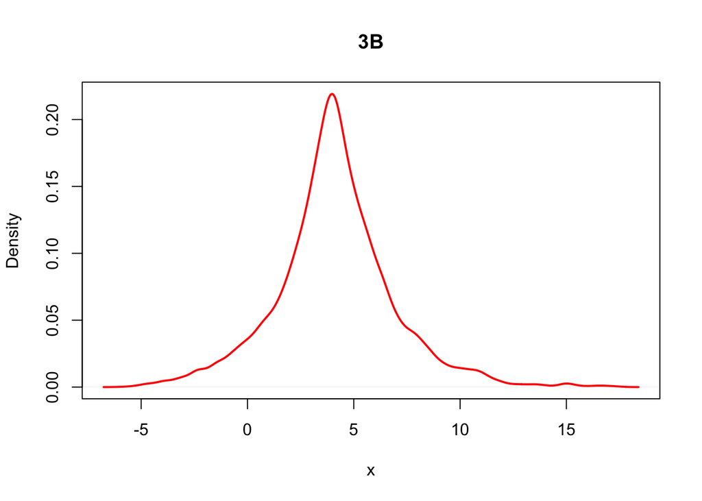

```r
mhAlgo <- function(N,mu,b){
  resVec <- rep(0,N)
  for (i in 2:N){
    s <- resVec[i-1]
    t <- runif(1, s-1, s+1)
    alfa <- exp( (abs(s-mu)-abs(t-mu))/b ) #Acceptance function
    u <- runif(1)
    if(u <= alfa){
      resVec[i] <- t
    }else{
      resVec[i] <- s
    }
  }
  return(resVec)
}


mhLaplace <- mhAlgo(10000,4,2)
plot(density(mhLaplace),col ="red", main="3B", xlab = "x", lwd=2)
```

### c)

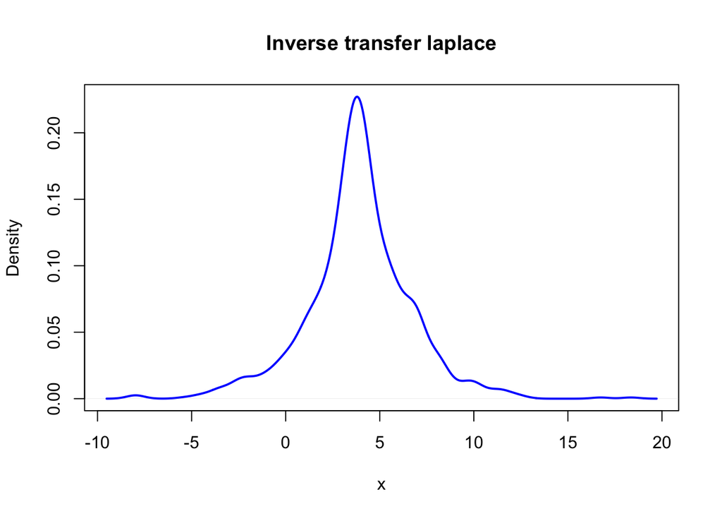

```r
invTransf <- function(Nsim,mu,b){
  U <- runif(Nsim)
  resVec <- vector(length=Nsim)
  for(i in 1:Nsim){
    resVec[i] <- mu-b*sign(U[i]-0.5)*log(1-2*abs(U[i]-0.5))

  }
  return(resVec)
}

laplace <- invTransf(1000,4,2)
#hist(laplace)
plot(density(laplace),col ="blue", main="Inverse transfer laplace", xlab = "x",lwd=2)
```

```r
##Estimate its fourth moment E(X^4) by basic Monte Carlo integration
mcFourthMoment <- function(a,b,laplace,moment,Nsim=1000){
  laplace <- approxfun(density(laplace))
  x <- runif(Nsim,a,b)
  intres <- (b-a)*mean((x^moment)*laplace(x))
  return(intres)
}


##Estimate its fourth moment E(X^4) by antithetic varables
antitheticFourthMoment <- function(a,b,laplace,moment,Nsim=1000){
  laplace <- approxfun(density(laplace))
  U <- runif(Nsim/2,a,b)
  V <- ((a+b)-U)
  intres <- ((b-a)/(Nsim))*( sum((U^moment)*laplace(U)) +sum((V^moment)*laplace(V))   )
  return(intres)
}

#repeat 1000 times and calculate the mean and sd
cmcVec <- vector(length=1000)
antVec <- vector(length=1000)
for(i in 1:1000){
  laplace <- invTransf(1000,4,2)
  a <- min(laplace)
  b <- max(laplace)
  cmcVec[i] <- mcFourthMoment(a,b,laplace,4)
  antVec[i] <- antitheticFourthMoment(a,b,laplace,4)
}

#Exact value
laplaceFunction <- function(x,moment=4,b=2,mu=4){
  (x^moment)*(1/(2*b))*exp(-abs(x-mu)/(b))
}

a <- min(laplace)
b <- max(laplace)


means= data.frame("Monte Carlo"=mean(cmcVec),"Antithetic"=mean(antVec),"Integrate"=integrate(laplaceFunction,-Inf,Inf)[[1]])
stdDevs= data.frame("Monte Carlo"=sd(cmcVec), "Antithetic"=sd(antVec))
kable(means, caption= "E[X^4]")
```

E[X^4]

| Monte.Carlo | Antithetic | Integrate |
| --- | --- | --- |
| 1372.639 | 1371.473 | 1408 |

```r
kable(stdDevs, caption= "SD[X^4]")
```

SD[X^4]

| Monte.Carlo | Antithetic |
| --- | --- |
| 176.3614 | 173.9362 |

### d)

(From the lecture notes chap6_part2)

Consider integrals which can be interpreted as expectations, i.e.
$$\theta=E(g(X))$$
If there exist a function h such that $\mu=E(h(X))$ is known and h(x) is correlated with g(x). Then for
$$\hat{\theta_{c}}=g(X)+c(h(X)-\mu)$$
we have for any c
$$E(\hat{\theta_{c}})=E(g(X))+c(E(h(X))-\mu)=\theta$$
where h(X) is the control variable. Then for
$$E(Xe^{sin(X)/(1+|X|})$$
we set $g(x)=Xe^{sin(X)/(1+|X|} \implies E(g(x))=\theta$. From the description we have $\mu=E(h(x))=E(X)$ and hence for any c we know that $E(\hat{\theta_{c}}) = E(Xe^{sin(X)/(1+|X|}) = \theta$. The final estimate of the integral is
$$\hat{\theta_{c}}=\overline{g(X)}+c^{*}(\overline{h(X)}-\mu)$$
where
$$c^{*}=-\frac{Cov(g(X),h(X))}{Var(h(X))}$$
We use the control variable h(X) together with knowledge from the description:
$$Var(h(X))=Var(X)=2b^{2}$$

### e)

$$1. L(b) = f(x_{1},...x_{N};b)=\prod_{i=1}^{N}f(x_{i};b)=\prod_{i=1}^{N}(\frac{1}{2b})e^{\frac{|x_{i}-\mu|}{b}}$$

$$\implies \prod_{i=1}^{N}(\frac{1}{2b})^{N}e^{-\frac{1}{b}\sum_{i=1}^{N}|x_{i}-\mu|}$$
$$2. lnL(b) = ln(1)-ln((2b)^{n}) + ln(e^{-\frac{1}{b}\sum_{i=1}^{N}|x_{i}-\mu|})$$
$$\implies -Nln(2b) -\frac{1}{b}\sum_{i=1}^{N}|x_{i}-\mu|$$
$$3. \frac{\partial l(b)}{\partial b} = 0$$
$$\implies -\frac{N}{b} +\frac{1}{b^{2}}\sum_{i=1}^{N}|x_{i}-\mu| = 0$$
$$\iff N = \frac{1}{b}\sum_{i=1}^{N}|x_{i}-\mu|$$
$$\implies \hat{b} = \frac{1}{N}\sum_{i=1}^{N}|x_{i}-\mu|$$
$$4. \frac{\partial^{2}l(b)}{\partial b^{2}}= -\frac{1}{b^{2}}\sum_{i=1}^{N}|x_{i}-\mu| <0, \quad i.e. maximum$$
Two additional estimators based on the description:
$$E(X) = \frac{1}{n}\sum_{i=1}^{n}X_{i} = \mu = \hat{\mu}$$
$$Var(X) = 2b^{2}$$
$$\implies \frac{1}{n-1}\sum_{i=1}^{n}(X_{i}-\bar{X})^{2} = 2b^{2}$$
$$\implies \hat{b} = \sqrt{\frac{1}{2(n-1)}\sum_{i=1}^{n}(X_{i}-\bar{X})^{2}}$$
We can use the bootstrap procedure to estimate the bias and standard deviation for all our estimators. Based on a known F with sample size n (defined by us), ($F_{n}$) and an estimator $\hat{\theta}$, we can look at the distribution of $\hat{\theta}$ about $\theta$. This is accomplished by taking a large number B (e.g 2000), of samples from $F_{n}$, then for each sample we calculate the estimator $\hat{\theta_{i}}$ where i = i,..,B. From this estimate, compute sd and bias. A simulation algorithm for this is is shown in f).

### $f)^R$

```r
MLEb <- function(x,mu){
  mean(abs(x-mu))
}

VARb <- function(x){
  n <- length(x)
  sqrt(((1)/(2*(n-1)))*(sum((x-mean(x))^2)) )
}

#Compute bias, standard deviation and mean square error using the bootstrap method
bootstrapResampling <- function(B,dataset,sampleSize){
  mleb <- vector(length=B) #Estimator of b based on the MLE
  varb<-  vector(length=B) #Estimator of b based on var(X) = 2b^2
  meanmu <- vector(length=B) #Estimator of mu based on E(X) = mu
  medianmu <- vector(length=B) #Estimator of mu based on mu=sample median
  for(i in 1:B){
    mleb[i] <- MLEb(sample(dataset,sampleSize,replace=TRUE),4)
    varb[i] <- VARb(sample(dataset,sampleSize,replace=TRUE))
    meanmu[i] <- mean(sample(dataset,sampleSize,replace=TRUE))
    medianmu[i] <- median(sample(dataset,sampleSize,replace=TRUE))
  }
  return(list("mleb" = mleb, "varb" = varb, "meanmu" = meanmu, "medianmu" = medianmu) )
}
laplaceVec <- rlaplace(1000,4,2)
laplaceBootstrap <- bootstrapResampling(2000,laplaceVec,500)

##Store bias, standard error and MSE for all the estimators
bias <- round(c(mean(laplaceBootstrap$mleb)-2,
                mean(laplaceBootstrap$varb)-2,
                mean(laplaceBootstrap$meanmu)-mean(laplaceVec),
                mean(laplaceBootstrap$medianmu)-mean(laplaceVec)),4)

sd <- round(c(sd(laplaceBootstrap$mleb), sd(laplaceBootstrap$varb),
              sd(laplaceBootstrap$meanmu), sd(laplaceBootstrap$medianmu)),4)

MSE <- round(c(mean((laplaceBootstrap$mleb-2)^2), #MSE = E[(thetahat-theta)^2] Hva er theta?
               mean((laplaceBootstrap$varb-2)^2),
               mean((laplaceBootstrap$meanmu-4)^2),
               mean((laplaceBootstrap$medianmu-4)^2)),4)


restab=cbind(c("b MLE", "b alt.","mu alt.","mu MLE"),bias,sd,MSE)
kable(restab, caption= "Estimators")
```

Estimators

|  | bias | sd | MSE |
| --- | --- | --- | --- |
| b MLE | -0.1397 | 0.0796 | 0.0258 |
| b alt. | -0.1631 | 0.0813 | 0.0332 |
| mu alt. | -0.0034 | 0.1126 | 0.0131 |
| mu MLE | 0.0973 | 0.0817 | 0.0129 |

### $g)^R$

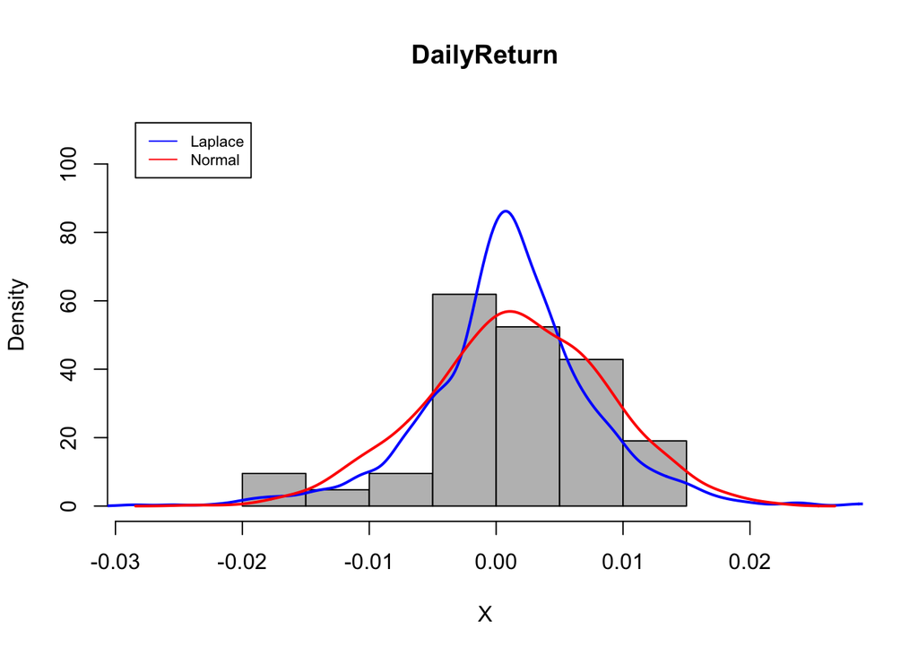

```r
DailyReturn = c(0.010842076,0.013009824,0.000910618,-9.40004*10^(-5),0.000322317,0.007229668,0.002879107,-0.000724356,-0.003135609,0.002581756,0.000342682,1.99552*10^(-5),-0.004895586,-9.69229*10^(-5),-0.008416394,0.006158565,-0.002428917,-0.005316326,0.005047623,-0.012258377,-0.01790324,0.007971991,0.014216853,-0.004478305,-0.015560826,0.009104547,0.006415702,0.010938931,-0.001387079,0.009955666,-0.001999546,0.002762828,-0.003919345,0.006871609,-0.003568673,0.002847139,0.00192044,0.004072697,0.00558138,-0.000832396,0.003253328,-0.003022873)
##


#Compute  point  estimates  of μ and b using  the  MLE  estimators from E
b <- MLEb(DailyReturn,mean(DailyReturn))
mu <- median(DailyReturn)
pdflaplace <- rlaplace(1000,mu,b)

#Compute point estimates of μ and σ by calculating the sample mean and the sample standard deviation
samplemu <- mean(DailyReturn)
samplesd <- sd(DailyReturn)
pdfnormal <- rnorm(1000,samplemu,samplesd)

#Histogram plots
xrange <- c(min(density(pdfnormal)$x),max(density(pdfnormal)$x))
yrange <- c(0,max( (density(pdflaplace)$y)*1.3) )

hist(DailyReturn, prob=TRUE, col="grey", main="DailyReturn", xlab="X", ylim=yrange, xlim=xrange)
lines(density(pdflaplace), col="blue", lwd=2)
lines(density(pdfnormal), col="red", lwd=2)
legend(xrange[1],yrange[2], legend=c("Laplace", "Normal"),
       col=c("blue", "red"), lty=1, cex=.7)
```

```r
# Comment on which of the two methods seem to estimate the dataset best
cat("Based on the plots. the best method is the normal distribution ")
```

```
## Based on the plots. the best method is the normal distribution
```

### $h)^R$

```r
bootstrapDailyReturn <- function(B,dataset,sampleSize){
  MLEestimator <- vector(length=B)
  for(i in 1:B){
    MLEestimator[i] <- median(sample(dataset,sampleSize,replace=TRUE))
  }
  return(MLEestimator)
}

bootstrapDR <- bootstrapDailyReturn(2500,DailyReturn,50)
bias <- mean(bootstrapDR)-median(DailyReturn)
correctedEstimate <- median(DailyReturn)-bias
sd <- sd(bootstrapDR)
#Basic confidence interval
basicLowerB <- 2*mean(DailyReturn)-quantile(bootstrapDR,0.975)
basicUpperB <- 2*mean(DailyReturn)-quantile(bootstrapDR,0.025)

#Use boot.ci for BCa confidence interval
BCa <- function(dataset,i)
  median(dataset[i])

boot.obj <- boot(data=DailyReturn, statistic = BCa,R=2500)
bcaint <- boot.ci(boot.obj,type=c("basic","bca"))

biasres <- c(bias,correctedEstimate, sd)
bcares <- c(bcaint$bca[4],bcaint$bca[5])
basicres <- c(basicLowerB[[1]],basicUpperB[[1]],bcaint$basic[4],bcaint$basic[5])

kable(data.frame("bias"=bias,"Bias corrected estimate"=correctedEstimate,
           "sd"=sd),caption="Bootsrap")
```

Bootsrap

| bias | Bias.corrected.estimate | sd |
| --- | --- | --- |
| 0.0004776 | 0.000149 | 0.0011563 |

```r
kable(data.frame("Basic lower"=basicres[1],"Basic upper"=basicres[2],"boot.ci lower"=basicres[3], "boot.ci upper"=basicres[4]) ,caption="Basic confidence intervals")
```

Basic confidence intervals

| Basic.lower | Basic.upper | boot.ci.lower | boot.ci.upper |
| --- | --- | --- | --- |
| -0.000913 | 0.0026179 | -0.0018129 | 0.0020857 |

```r
kable(data.frame("BCa lower"=bcares[1],"BCa upper"=bcares[2]) ,caption="BCa confidence interval")
```

BCa confidence interval

| BCa.lower | BCa.upper |
| --- | --- |
| -0.0010557 | 0.0030502 |

# Problem 4

### $a)^R$

```r
hospitalTimes <- function(numAcc,expected){
  totalTimes <- vector(length=numAcc)
  peopleInAcc <- sample(c(1:4), size = numAcc, prob=c(0.4,0.3,0.2,0.1), replace = TRUE)
  for(i in 1:numAcc){ #duration for an accident
    rate <- 1/(expected*(abs(runif(1,-1,1))+abs(runif(1,-1,1))))
    totalTimes[i] <- sum(rexp(peopleInAcc[i],rate))
  }
  return(totalTimes)
}

simBusyAmbulance <- function(Nsim,rate1,rate2,days){
  numAcc <- rpois(Nsim,rate1*days)
  resVec <- rep(0,Nsim)
  for(i in 1:Nsim){
    if(numAcc[i] > 1){ #Simulate if it was an accident
      startTimes <- sort(runif(numAcc[i],min=0,max=24*days))
      durations <- hospitalTimes(numAcc[i],rate2)/60
      endTimes = startTimes+durations
      resVec[i]= max((startTimes[2:numAcc[i]]-endTimes[1:(numAcc[i]-1)])<0)
    }
  }
  return(resVec)
}

mean(simBusyAmbulance(Nsim=1000,rate1=4.8,rate2=15,days=1))
```

```
## [1] 0.317
```

```r
mean(simBusyAmbulance(Nsim=1000,rate1=4.8,rate2=15,days=7))
```

```
## [1] 0.943
```

```r
mean(simBusyAmbulance(Nsim=1000,rate1=4.8,rate2=15,days=31))
```

```
## [1] 1
```

### b)

Given a sequence of observations $X_{1},..,X_{n}$ we may test whether there is a trend, e.g. it becomes larger or smaller over time. The current model states that the accidents happen according to a HPP without a trend. The group of statisticians thinks that the accidents happen more frequently over time, and hence a permutation test of the sequence of subsequent arrival times can be applied.

This trend test is a test of the null hypothesis H0:

- F=G $\implies$ Frequency between accidents happens according to a Poisson process, e.g. no trend.

versus the alternative H1:

- F $\ne G \implies$ $E(X_{i})$ increase or decrease with i, e.g. happens according to a NHHP (process with a trend).

Let $S_{1}=X_{1}, S_{2}=X_{1}+X_{2},..,S_{n}=\sum_{i=1}^{n}X_{i}$. The averages of $S_{1},..,S_{n-1}$ should be close to $S_{n}/2$ if there is no trend, else it will deviate. The test statistic is defined as:
$$T=\sum_{i=1}^{n-1}S_{i}/(n-1)-S_{n}/2$$
Under H0, $X_{1},..,X_{n}$ are i.i.d. and can thus be re-arranged in any order. Under the permutation test, we will compare T to the distribution of $T^{*}$ , which we simulates by calculating test statistics for a large number of permutations of the observations. The permutation test can be performed like this:

1. Define our test statistic T based on observed data $X_{1},..,X_{n}$
2. Permutate the dataset P times, and calculate $T^{*}$ for each run
3. Calculate the p-value: $\sum_{p=1}^{P}I(|T^{*(p)}|>T)/P$
4. Reject H0 if p-value <= $\alpha$, where $\alpha$ is the significanse level.

### $c)^R$

```r
AccidentTimes = c(2.0735454,8.4167032,1.1005269,2.0120367,14.9385790,0.8956173,0.9939630,6.6709724,2.5516346,1.0535310,3.0399767,1.0439586,6.9407880,4.6048051,2.2845416,0.1220334,9.1797608,1.3015252,2.7024692,1.4658722,1.4774836,2.1170539,1.6563365,3.8815059,1.4736501,2.1680797,2.7599514,0.8482105,2.1241656,3.3280075,5.5765849,3.9268892,5.1796726,2.5678380,5.9643887,1.4045580)
##
trendTest <- function(dataset,numObs){
  mean(dataset[1:(numObs-1)])-dataset[numObs]/2
}

trendPermutationTest <- function(P,dataset,alfa){
  resVec <- vector(length=P) #Store permutated test data
  sValues <- cumsum(dataset) #S1,..Sn
  orgTest <- mean(sValues[1:(length(dataset)-1)])-sValues[length(dataset)]/2 #Test for the original data
  for(i in 1:P){
    permData <- cumsum(sample(dataset,size=length(dataset),replace=FALSE)) #S1,..Sn for permutated data
    resVec[i] <- trendTest(permData,length(dataset))
  }
  mean(abs(resVec)>=abs(orgTest)) #p-value
}

pval <- trendPermutationTest(5000,AccidentTimes,0.2)

alpha <- 0.05
cat(ifelse(pval <= alpha,"We reject the null hypothesis, there is a trend","We keep the null hypothesis, there is no trend"))
```

```
## We keep the null hypothesis, there is no trend
```

### $d)^R$

```r
lambdaFunction <- function(x){
  0.2*(1 + 0.5*sin( (pi*x)/(24) ))
}

busyAmbulanceCheck <- function(arrivalTimes, endTimes, k){
  if(length(arrivalTimes) <= k){
    return(0)
  }
  finishTimes <- endTimes[1:k] #endtimes for all ambulances on a mission
  for(i in (k+1):length(arrivalTimes)){
    if(arrivalTimes[i] < min(finishTimes)){ #No available
      return(1)
    }
    #Append new mission to the ambulance that is finished first
    finishTimes[which(finishTimes == min(finishTimes))] <- endTimes[i]
  }
  return(0)
}


simNHHPBusyAmbulance <- function(Nsim,rate1,rate2,days){
  kScores <- list() #probability for each k
  k <- 1
  repeat{ #until probability lower than 0.1
    resVec <- rep(0,Nsim[k]) #Store if ambulance busy during sim: 1 if busy, 0 else
    for(i in 1:Nsim[k]){
      #1. Simulate an HPP with intensity lamdamax, giving the simulated arrivaltimes s1,s2,s3..sn
      lambdamax <- max(lambdaFunction(seq(0,24*days,0.1)))
      expectednumber <- 24*days*lambdamax
      arrivalTimes <- cumsum(rexp(3*expectednumber,lambdamax))
      arrivalTimes <- arrivalTimes[arrivalTimes<(24*days)]
      #2. Simulate numAcc variables from the U[0,1] distribution
      U <- runif(length(arrivalTimes) )
      #3. Thinning: Only keep the times where u<lambda(s)/lambdamax
      arrivalTimes <- arrivalTimes[U<lambdaFunction(arrivalTimes)/lambdamax]
      numAcc <- length(arrivalTimes)

      if(numAcc > 1){ #Simulate if it was an accident
        durations <- hospitalTimes(numAcc,rate2)/60
        endTimes = arrivalTimes+durations
        resVec[i] <- busyAmbulanceCheck(arrivalTimes,endTimes,k)
      }
    }
    kScores[[k]] <- resVec
    if(mean(kScores[[k]]) < 0.1){
      break
    }
    k <- k + 1
  }

  return(kScores)
}

simulationsNeeded <- function(sd){
 round(( (1.96^2)*(sd^2) )/(0.01^2))
}

#Evaluate the base score with 1000 simulations
baseSim <- simNHHPBusyAmbulance(Nsim=rep(1000,100),rate1=4.8,rate2=15,days=1)
baseSD <- lapply(baseSim, function(x) sd(x))
baseMean <- unlist(lapply(baseSim, function(x) mean(x)), use.names=FALSE)
simNum <- unlist(lapply(baseSD, simulationsNeeded), use.names=FALSE) #Number of simulations needed for each k
#Run with the produced simulation numbers
finalSim <- simNHHPBusyAmbulance(Nsim=unlist(simNum, use.names=FALSE),rate1=4.8,rate2=15,days=1)
finalMean <- unlist(lapply(finalSim, function(x) mean(x)), use.names=FALSE)


res <- data.frame("k"=seq(length(finalMean)),"Nsim"=simNum,"Base_prediction"=baseMean, "Final_prediction"=finalMean)

kable(res,  caption= "Probability of no available ambulance")
```

Probability of no available ambulance

| k | Nsim | Base_prediction | Final_prediction |
| --- | --- | --- | --- |
| 1 | 9574 | 0.468 | 0.4862127 |
| 2 | 1547 | 0.042 | 0.0465417 |